# Variant Calling pipeline for Lab Lab

Group 6

26/08/2020

**Variant Calling for Lab Lab**

**Variant calling** refers to the process of identifying a single or many nucleotides or long stretches of DNA from a query that are different from the reference sequence.

**Variant types**

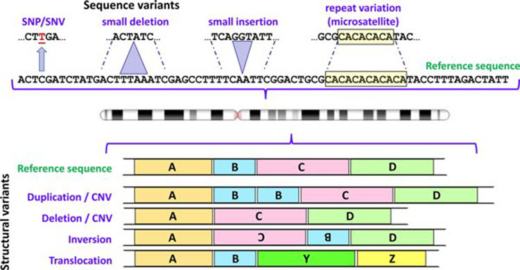

Why Variant calling for Lab Lab?

This process will enhance identification of molecular markers that can be exploited in increasing the productivity of this crop.

# Setting up the environment

```
conda create --name variant

conda install snakemake

# Linux based
conda install python=3.6
conda config --add channels bioconda
conda config --add channels defaults
conda config --add channels conda-forge
conda install -y -c bioconda nanoqc
conda install -y -c bioconda porechop
conda install -y -c bioconda samtools
conda install -y -c bioconda minimap2
conda install -y -c bioconda ngmlr
conda install -y -c bioconda freebayes
conda install -y -c bioconda sniffles
conda install -y -c bioconda snakemake
conda install -y -c bioconda rtg-tools
```

In running the pipeline a few things have to be changed in the snakefile including the name of the reference and the data location must be checked for consistency.

# Output from the pipeline

*NB:*

Other variant calling processes are still running

**Future:**

Need to polish up the pipeline and incorporate the assembly pipeline into the whole pipeline; running from assembly to variant calling.

You may want to consider variant calling using different tools and algorithms and comparing their outputs.

# Challenges faced

. Due to limited computational power we could not succesfully perform reassembly of the 147D genomes.

. Thus we requested our supervisors to provide us with existing assemblies for variant calling

Minimap2 when used in mapping the long reads to illumina assembly it is unable to resolve the structural variants, missing string during structural variant calling by sniffles.

To solve this we encourage use a long read mapper, *ngmlr* then pipe that into sniffles.